# CSCI Simulating Functions

QThi

23 July, 2019

## Functions

This project requires three dataset: `tblgismetrics` and `tbl_taxonomyresults` from database, `station_list` from data folder

### Prep data

#### Picking site

```r
datmetcon <- tbl(con, 'tmp_phabmetrics')
datrawcon <- tbl(con, 'tmp_phab')
datgiscon <- tbl(con, 'tblgismetrics')
datbugcon <- tbl(con, 'tbl_taxonomyresults')
CSCIcore <- tbl(con, 'csci_core')

station_list <- read_csv("data/station_list.csv")

# Site data
gis <- as_tibble(datgiscon)  %>%
  select("stationcode", "area_sqkm", "bdh_ave",
         "elev_range", "kfct_ave", "p_mean",
         "new_lat", "new_long", "ppt_00_09",
         "site_elev", "sumave_p", "temp_00_09")
# Bug data
bug_origin <- as_tibble(datbugcon) %>%
  select("stationcode", "sampledate", "fieldreplicate",
         "fieldsampleid","finalid", "lifestagecode",
         "baresult", "result", "unit",
         "distinctcode")%>%
  mutate(
    baresult = as.numeric(baresult)
  )

# Fix names
colnames(bug_origin) <- c("StationCode","SampleDate","SampleID",
                   "FieldSampleID", "FinalID", "LifeStageCode",
                   "BAResult", "Result", "Unit",
                   "distinct")

colnames(gis) <- c("StationCode", "AREA_SQKM", "BDH_AVE",
                   "ELEV_RANGE", "KFCT_AVE", "P_MEAN",
                   "New_lat", "New_Long", "PPT_00_09",
                   "SITE_ELEV", "SumAve_P", "TEMP_00_09")
```

Steps for simulating scores

- Step 1: pick site (StationCode) from a dataset called `station_list`
  - This list was created based on a list of sites from Raphi and the two data set mentioned above
  - Number of bugs for each site is around 500-600
  - Collection method code is either BMI_RWB_MCM or BMI_RWB.
- Step 2: Reformating the data (names, columns) to feed into the function.

#### Preparing bugs

```r
prep_bug_data <- function(bug_origin, site){
  bug.site <- bug_origin %>%
    filter(StationCode == site) %>%
    filter(SampleDate == max(SampleDate)) %>%
    filter(SampleID == max(SampleID))
  bug.site.clean <- CSCI::cleanData(bug.site, purge = T, message = F)
  return(bug.site.clean)
}
```

This function

- filters data from original bug data `tbl_taxonomyresults` to get the data for chosen site.
- cleans the data by **cleanData()**
- returns clean bug data

### Sub-sampling

#### Sub-sampling bug

```r
sub_sampling_chosen_site <- function(bug_origin, site, num_bug){
  clean_site <- prep_bug_data(bug_origin, site)
  bug.expand <- clean_site %>%
    uncount(as.numeric(BAResult)) %>%
    mutate_at("BAResult", 1)
  ind <- sample(1:nrow(bug.expand), num_bug, replace = F)
  bug.pick <- bug.expand[ind,]
  return(bug.pick)
}
```

Since we only want to simulate scores over a specific amount of bugs, we would want to sub-sample the chosen bug data from **prep_bug_data()**.

- `num_bug` is the amount of bugs we want to sample
- **uncount(value)** replicates the line `value` times.
- randomly samples 500 indices for rows.

### Simulation

```r
simulating_bugs_and_scores <- function(bug_origin, site, gis, it, inc, num_bug, num_bug_start){
  sub_sampling_chosen_site(bug_origin, site, num_bug)
  gis.station <- gis %>%
    filter(StationCode == site)
  nb <- seq(num_bug_start, num_bug, by = inc)
  bug.pick <- sub_sampling_chosen_site(bug_origin, site, num_bug)

  res <- foreach(i = 1:length(nb), .packages = c("tidyverse", "CSCI") ) %dopar% {
    core_res <- c()
    mmi_res <- c()
    grp_res <-c()
    omni_res <- c()
    for (j in 1:it){
      if(nb[i] == num_bug){j = it}
      ind <- sample(1:nrow(bug.pick), nb[i], replace = F)
      bugs <- bug.pick[ind,] %>%
        count(BAResult, FinalID, LifeStageCode,
              SampleDate, SampleID, Result,
              Unit, distinct, FieldSampleID, StationCode) %>%
        mutate(BAResult = n)
      gis <- gis.station
      omni <- CSCI(bugs,gis)
      omni_res[[j]] <- omni
      core_res[[j]] <- omni$core
      mmi_res[[j]] <- omni$Suppl1_mmi
      grp_res[[j]] <- omni$Suppl1_grps
    }
    list(core_res,
         mmi_res,
         grp_res,
         omni_res)

    save(res, file = paste0("stations/", site, ".RData"))
    return()
  }
}
```

### Tidy, summarize

#### Tidying_simulated_data

```r
tidying_simulated_data <- function(site){
  load_dir <- paste0("stations/", site, ".RData")
  load(load_dir)
  res1 <- res %>% enframe()
  result <- c()

  for (i in 1:nrow(res1)){
    result[[i]]<- res[[i]] %>%
      enframe() %>%
      filter(name != 4) %>%
      deframe()
  }

  omni_data <- result %>%
    modify_depth(.depth = 2, .f = ~as_tibble(bind_rows(.))) %>%
    modify_depth(.depth = 1, .f = ~as_tibble(bind_cols(.))) %>%
    bind_rows() %>%
    select(-c(StationCode1, StationCode2, SampleID1))

  return(omni_data)
}
```

- Loads in saved data from **simulating_bug_and_score()** in stations folder
- Reformats the data with **modify_depth()** function, the output is a tibble
  - Count: number of bugs in each iterations
  - The rest of the columns have the format of **CSCI()** output with columns combined for each iteration.

#### Summarizing_tidied_data

```r
summarising_tidied_data <- function(site){
  omni_data <- tidying_simulated_data(site)

  summary_data <- omni_data %>%
    group_by(Count) %>%
    select(Count, MMI, CSCI, OoverE) %>%
    summarise_all(.,
                  list(~mean(.),
                       ~sd(.),
                       ~quantile(., probs = 0.025),
                       ~quantile(., probs = .975))
    )
  return(summary_data)
}
```

- Calcualate means, standard deviations, and bounds of each scores obtained from simulation

#### subsampling.site.info

```r
subsampling.site.info <- function(site, station_list){
  site_pick_core <- tidying_simulated_data(site) %>%
    filter(Count == 500) #num_bug = 500

  site <- site_pick_core$StationCode
  site_csci <- site_pick_core$CSCI
  site_mmi <- site_pick_core$MMI
  site_oovere <- site_pick_core$OoverE

  site_info <- station_list %>%
    filter(StationCode == site) %>%
    filter(SampleDate == max(SampleDate))
  site_bug <- site_info$Count

  return(list(site = site,
              csci = site_csci,
              mmi = site_mmi,
              oovere = site_oovere,
              cnt = site_bug))
}
```

- returns orginal information about the chosen site
- information about the last iteration is useful for plot and labels

### Fitting models

```r
summaried_data_with_models_to_csci_mean <- function(site, station_list){

  scores <- subsampling.site.info(site, station_list)
  site_csci <- scores$csci
  site_mmi <- scores$mmi
  site_oovere <- scores$oovere
  site_bug <- scores$cnt

  summary_data <- summarising_tidied_data(site)
  mean_test <- summary_data %>%
    select(Count, CSCI_mean)

  x <- mean_test$Count
  y <- mean_test$CSCI_mean
  sph_model = nls(y ~ c0s + cs*(1.5*abs(x)/as - .5*(abs(x)/as)^3),
                  start = list(c0s = 0.4, cs = 0.9, as = 400), trace = F)
  temp <- summary(sph_model)$coef
  c0s = temp[1,1]
  cs = temp[2,1]
  as = temp[3,1]

  exp_model = nls(y~c0e + ce*(1-exp(-abs(x)/ae)),
                  start = list(c0e = 0.3, ce = 0.9, ae = 200), trace = F)
  temp1 <- summary(exp_model)$coef
  c0e = temp1[1,1]
  ce = temp1[2,1]
  ae = temp1[3,1]
  x1 <- x
  spher <- (c0s + cs*(1.5*abs(x1)/as - .5*(abs(x1)/as)^3)) *
    (x1 <= as) + (c0s+cs)*(x1 > as)
  expo <- (c0e + ce*(1-exp(-abs(x1)/ae)))
  summary_model_data <- add_column(summary_data, Sphere = spher, Expo = expo)

  est_data <- tibble(count = site_bug,
                     CSCI = site_csci,
                     MMI = site_mmi,
                     OoverE = site_oovere,
                     nugget_s = c0s, nugget_e = c0e,
                     sill_s = cs, sill_e = ce,
                     range_s = as, range_e = ae,
                     delta = as-ae)

  return(list(summ = summary_model_data,
              est = est_data)
         )
}
```

Since we are interested in the least number of bugs we need in order to trust *CSCI()* output, we would want to run a model (variograms) on the mean of CSCI score.

- **nls()** is used to find points of convergence
  - x = Count, y = CSCI_mean
  - function: spherical or exponential.
  - starting values are set to be reasonable to fit into all data.
- Adding values from spherical/exponential functions (y’s) to `summary_data`
- returning
  - tibble with summary information of iterations, models fitted values
  - tibble with nugget, sill, and range information for the two fitted models.

### Producing plots

```r
scores_plot <- function(site, station_list){
  scores <- subsampling.site.info(site = site, station_list= station_list)
  site_csci <- scores$csci
  site_mmi <- scores$mmi
  site_oovere <- scores$oovere
  site_bug <- scores$cnt

  data <-  summaried_data_with_models_to_csci_mean(site, station_list)
  summary_data <- data$summ
  model_data <- data$est

  ae = model_data$range_e
  as = model_data$range_s

  CSCI_plot <- summary_data %>%
    ggplot() +
    geom_point(aes(Count, CSCI_mean)) +
    geom_line(aes(Count,CSCI_quantile..3), color = "blue",
              size = 0.4, linetype = 4) +
    geom_line(aes(Count, CSCI_quantile..4), color = "blue",
              size = 0.4, linetype = 4) +
    geom_line(aes(Count, Sphere, color = "Spherical"), size = 1) +
    geom_line(aes(Count, Expo, color = "Exponential"), size = 1) +
    geom_hline(yintercept = site_csci, linetype = 3) +
    geom_hline(yintercept = (site_csci -.1), linetype = 3) +
    geom_hline(yintercept = (site_csci +.1), linetype = 3) +
    geom_vline(xintercept = ae, color = "darkgreen", linetype = 4) +
    geom_vline(xintercept = as, color = "red", linetype = 4) +
    labs(x = "Sample size", y = "CSCI score",
         fill = "model") +
    scale_color_manual("",
                       breaks = c("Spherical", "Exponential"),
                       values = c("darkgreen", "red"))+
    ggtitle(paste("Station", site),
            subtitle = paste("CSCI score = ", round(site_csci,3), ", number of bugs = ", site_bug,
                             "\nrange: exponential: ", round(ae,2),
                             "\n           spherical:     ", round(as,2)))

  OoverE_plot <- summary_data %>%
    ggplot()+
    geom_line(aes(Count, OoverE_mean), color = "red",
              size = 0.7, linetype = 1) +
    geom_line(aes(Count, OoverE_quantile..3), color = "blue",
              size = 0.4, linetype = 4) +
    geom_line(aes(Count, OoverE_quantile..4), color = "blue",
              size = 0.4, linetype = 4) +
    labs(x = "Sample size", y = "Observed/Expected")+
    ggtitle(paste("Station ", site), subtitle = paste("bugs = ", site_bug,
                                                      ", O/E = ", round(site_oovere,3)))

  MMI_plot <- summary_data %>%
    ggplot()+
    geom_line(aes(Count, MMI_mean), color = "red",
              size = 0.7, linetype = 1) +
    geom_line(aes(Count, MMI_quantile..3), color = "blue",
              size = 0.4, linetype = 4) +
    geom_line(aes(Count, MMI_quantile..4), color = "blue",
              size = 0.4, linetype = 4) +
    labs(x = "Sample size", y = "MMI") +
    ggtitle(paste("Station ", site), subtitle = paste("bugs = ", site_bug,
                                                      ", MMI = ", round(site_mmi,3)))

  return(list(csci = CSCI_plot,
              oovere = OoverE_plot,
              mmi = MMI_plot,
              est = model_data))
}
```

There are three plots created:

- CSCI_plot: contains all the infomations about CSCI scores and the two model fits. Range (ideal number of bugs) for each model is included.
- MMI_plot: MMI score along with lower/upper bound of simulated data
- OoverE_plot: OoverE (Observed over Expected) score, lower/upper bounds

This function can be run with a **for** loop to go through all the available site data.

### Summary plot

```r
site_list <- c("SMCR8_277","SMC00476", "SGUR103",
               "SMC01424", "SMC01384", "801M16861","SMC02984")

summary_plot <- function(){
  simulated_data <- c()

  for(i in seq_along(site_list)){
    simulated_data[[i]] <- tidying_simulated_data(site = site_list[i])
  }
  simulated_data_bind <- bind_rows(simulated_data)
  summary_within_station <- simulated_data_bind %>%
    group_by(StationCode, Count) %>%
    select(StationCode, Count, CSCI, MMI, OoverE) %>%
    summarise_all(.,
                list(~mean(.),
                     ~sd(.)))

  test <- summary_within_station %>%
    gather('var', 'val', -StationCode, -Count) %>%
    separate(var, c('index', 'measure'), sep = '_') %>%
    group_by(StationCode, index, measure) %>%
    mutate(
      chng = val / max(val, na.rm = T)
    ) %>%
    ungroup %>%
    mutate(Count = 500 - Count)


  test %>%
    ggplot(aes(color = StationCode, group = StationCode)) +
    geom_line(aes(x = Count, y = chng)) +
    facet_grid(index ~ measure)


#relative difference

  test2 <- summary_within_station %>%
    gather('var', 'val', -StationCode, -Count) %>%
    separate(var, c('index', 'measure'), sep = '_') %>%
    group_by(StationCode, index, measure) %>%
    mutate(
      val = replace_na(val,min(val, na.rm = T)),
      chng = abs(val - last(val)) /max(val,last(val))
    ) %>%
    ungroup %>%
    mutate(Count = 500 - Count)

  test2 %>%
    ggplot(aes(color = StationCode, group = StationCode)) +
    geom_line(aes(x = Count, y = chng)) +
    labs( x = "Reduction of bug",
          y = "Relative difference",
          title = "Relative Difference of Mean and Standard Deviation for each Scores",
          subtitle = "As we decrease the number of bug, mean and standard deviation of scores
          (CSCI, MMI, O over E) differ significantly") +
    facet_grid(index ~ measure)+
    theme_bw()

}
```

- calculates changes and relative differences of mean and standard deviations of scores from simulated data
- outputs a summarized plot shows changes according to sample size

## Plots

```r
for (i in 1:7){
  load(here('Rmarkdown', glue::glue("site{i}.RData")))
}
```

### CSCI score

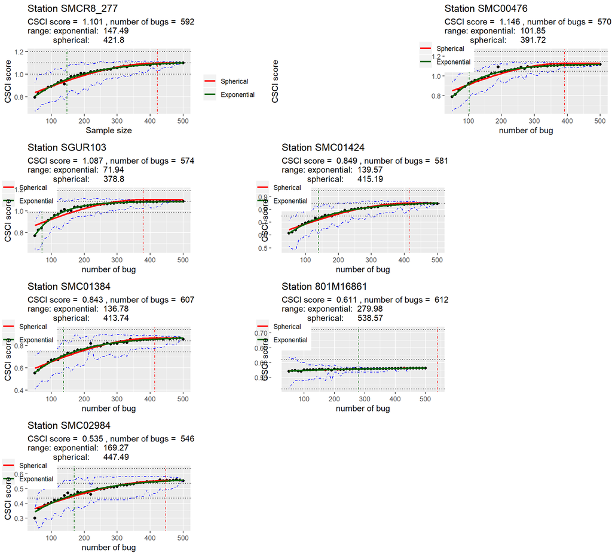

```r
site1$csci + site2$csci + site3$csci + site4$csci + site5$csci + site6$csci + site7$csci + plot_layout(ncol = 2)
```

### MMI

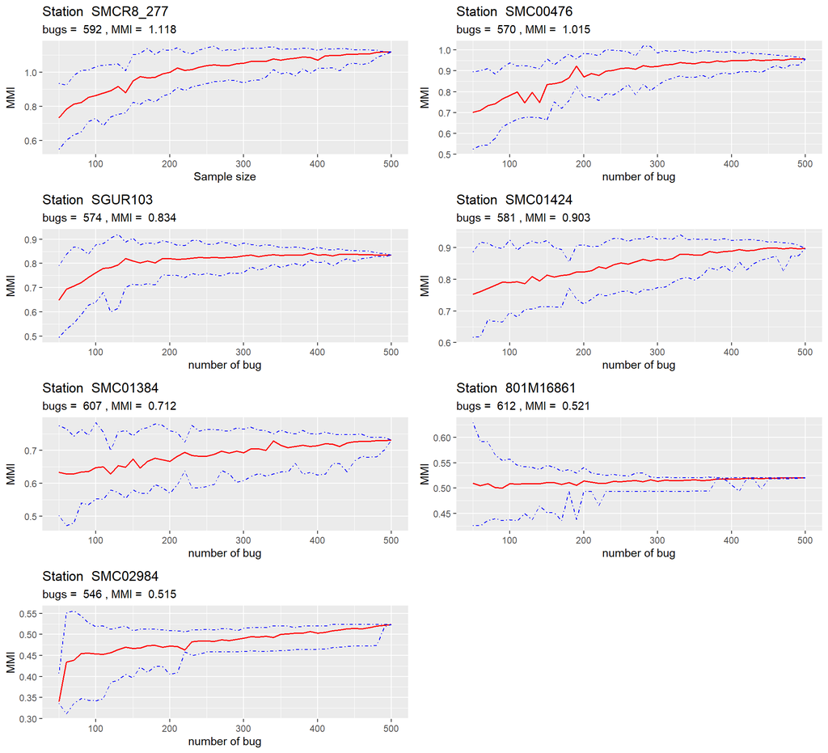

```r
site1$mmi + site2$mmi + site3$mmi + site4$mmi + site5$mmi + site6$mmi + site7$mmi + plot_layout(ncol = 2)
```

### OoverE

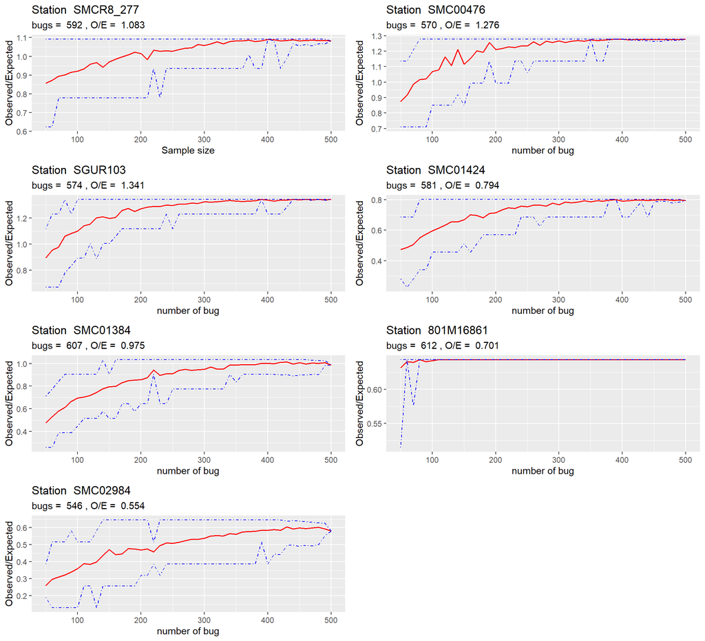

```r
site1$oovere + site2$oovere + site3$oovere + site4$oovere + site5$oovere + site6$oovere + site7$oovere + plot_layout(ncol = 2)
```

### ranked data

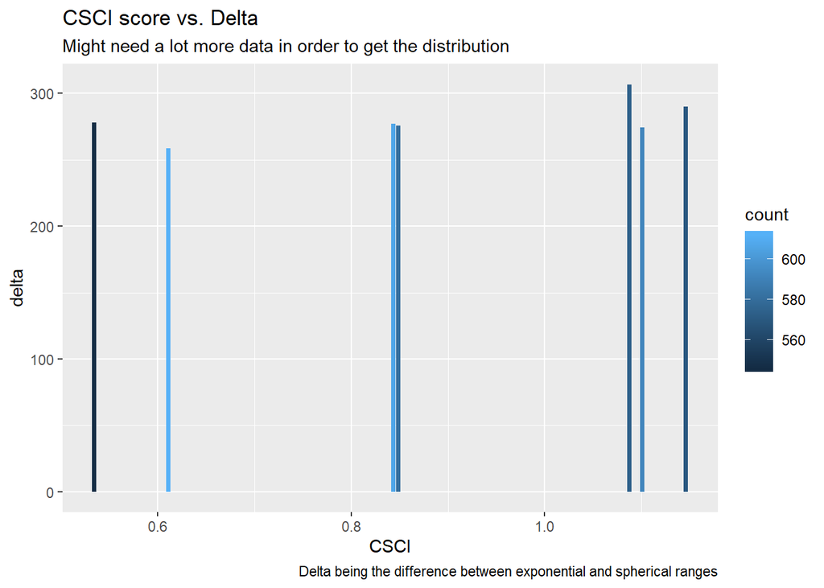

```r
ranked_data <- bind_rows(site1[['est']],
                         site2[['est']],
                         site3[['est']],
                         site4[['est']],
                         site5[['est']],
                         site6[['est']],
                         site7[['est']]
                         )


ranked_data %>%
  ggplot() +
  geom_col(aes(y = delta, x = CSCI, fill = count)) +
  labs(title = "CSCI score vs. Delta",
       subtitle = "Might need a lot more data in order to get the distribution",
       caption = "Delta being the difference between exponential and spherical ranges")
```

### Changes

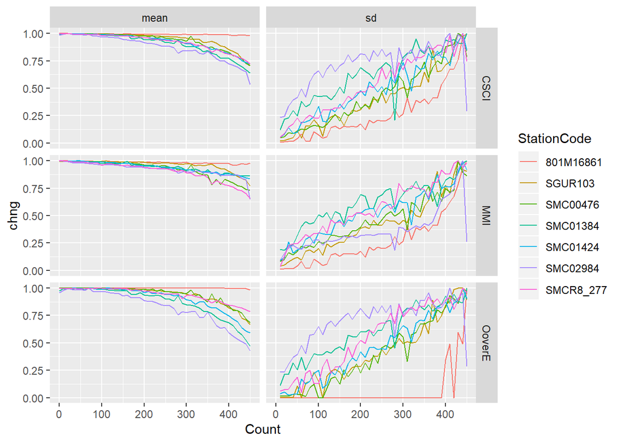

```r
load(here("Rmarkdown","sums.RData"))
sum1
```

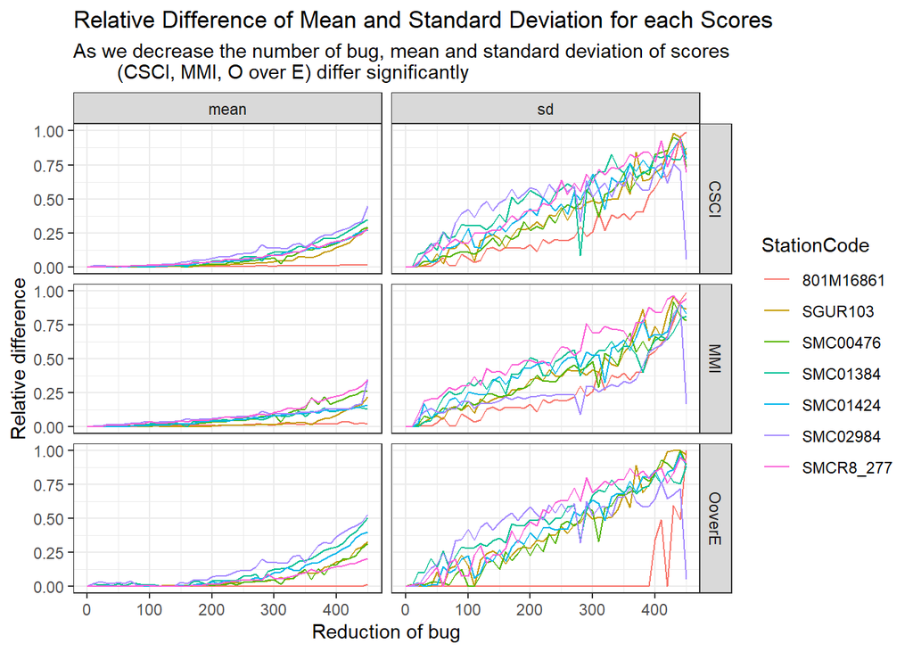

```r
sum2
```